# Risk Factor Analysis

## Outcome Variable

**Outcome Variable:** whz

## Predictor Variables

**Intervention Variable:** earlybf

**Adjustment Set:**

- arm
- sex
- W_mage
- meducyrs
- feducyrs
- hhwealth_quart
- hfoodsec
- W_mhtcm
- W_mwtkg
- W_mbmi
- vagbrth
- W_gagebrth
- W_birthwt
- W_birthlen
- W_nrooms
- W_nchldlt5
- brthmon
- W_parity
- impfloor
- impsan
- safeh20
- delta_W_mage
- delta_meducyrs
- delta_feducyrs
- delta_hhwealth_quart
- delta_hfoodsec
- delta_W_mhtcm
- delta_W_mwtkg
- delta_W_mbmi
- delta_vagbrth
- delta_W_gagebrth
- delta_W_birthwt
- delta_W_birthlen
- delta_W_nrooms
- delta_W_nchldlt5
- delta_brthmon
- delta_W_parity
- delta_impfloor
- delta_impsan
- delta_safeh20

## Stratifying Variables

The analysis was stratified on these variable(s):

- agecat
- studyid
- country

## Data Summary

| agecat | studyid | country | earlybf | n_cell | n | outcome_variable |
| --- | --- | --- | --- | --- | --- | --- |
| Birth | EE | PAKISTAN | 1 | 36 | 170 | whz |
| Birth | EE | PAKISTAN | 0 | 134 | 170 | whz |
| Birth | GMS-Nepal | NEPAL | 1 | 171 | 586 | whz |
| Birth | GMS-Nepal | NEPAL | 0 | 415 | 586 | whz |
| Birth | JiVitA-3 | BANGLADESH | 1 | 105 | 17943 | whz |
| Birth | JiVitA-3 | BANGLADESH | 0 | 17838 | 17943 | whz |
| Birth | JiVitA-4 | BANGLADESH | 1 | 1624 | 2396 | whz |
| Birth | JiVitA-4 | BANGLADESH | 0 | 772 | 2396 | whz |
| Birth | MAL-ED | BANGLADESH | 1 | 140 | 214 | whz |
| Birth | MAL-ED | BANGLADESH | 0 | 74 | 214 | whz |
| Birth | MAL-ED | BRAZIL | 1 | 26 | 62 | whz |
| Birth | MAL-ED | BRAZIL | 0 | 36 | 62 | whz |
| Birth | MAL-ED | INDIA | 1 | 31 | 44 | whz |
| Birth | MAL-ED | INDIA | 0 | 13 | 44 | whz |
| Birth | MAL-ED | NEPAL | 1 | 14 | 26 | whz |
| Birth | MAL-ED | NEPAL | 0 | 12 | 26 | whz |
| Birth | MAL-ED | PERU | 1 | 172 | 228 | whz |
| Birth | MAL-ED | PERU | 0 | 56 | 228 | whz |
| Birth | MAL-ED | SOUTH AFRICA | 1 | 69 | 110 | whz |
| Birth | MAL-ED | SOUTH AFRICA | 0 | 41 | 110 | whz |
| Birth | MAL-ED | TANZANIA, UNITED REPUBLIC OF | 1 | 103 | 115 | whz |
| Birth | MAL-ED | TANZANIA, UNITED REPUBLIC OF | 0 | 12 | 115 | whz |
| Birth | NIH-Crypto | BANGLADESH | 1 | 613 | 707 | whz |
| Birth | NIH-Crypto | BANGLADESH | 0 | 94 | 707 | whz |
| Birth | SAS-CompFeed | INDIA | 1 | 79 | 1072 | whz |
| Birth | SAS-CompFeed | INDIA | 0 | 993 | 1072 | whz |
| Birth | ZVITAMBO | ZIMBABWE | 1 | 6142 | 11514 | whz |
| Birth | ZVITAMBO | ZIMBABWE | 0 | 5372 | 11514 | whz |
| 6 months | EE | PAKISTAN | 1 | 69 | 364 | whz |
| 6 months | EE | PAKISTAN | 0 | 295 | 364 | whz |

[output cut: 52 more lines]

The following strata were considered:

- agecat: 24 months, studyid: EE, country: PAKISTAN
- agecat: 24 months, studyid: GMS-Nepal, country: NEPAL
- agecat: 24 months, studyid: JiVitA-3, country: BANGLADESH
- agecat: 24 months, studyid: JiVitA-4, country: BANGLADESH
- agecat: 24 months, studyid: MAL-ED, country: BANGLADESH
- agecat: 24 months, studyid: MAL-ED, country: BRAZIL
- agecat: 24 months, studyid: MAL-ED, country: INDIA
- agecat: 24 months, studyid: MAL-ED, country: NEPAL
- agecat: 24 months, studyid: MAL-ED, country: PERU
- agecat: 24 months, studyid: MAL-ED, country: SOUTH AFRICA
- agecat: 24 months, studyid: MAL-ED, country: TANZANIA, UNITED REPUBLIC OF
- agecat: 24 months, studyid: NIH-Crypto, country: BANGLADESH
- agecat: 24 months, studyid: ZVITAMBO, country: ZIMBABWE
- agecat: 6 months, studyid: EE, country: PAKISTAN
- agecat: 6 months, studyid: GMS-Nepal, country: NEPAL
- agecat: 6 months, studyid: JiVitA-3, country: BANGLADESH
- agecat: 6 months, studyid: JiVitA-4, country: BANGLADESH
- agecat: 6 months, studyid: MAL-ED, country: BANGLADESH
- agecat: 6 months, studyid: MAL-ED, country: BRAZIL
- agecat: 6 months, studyid: MAL-ED, country: INDIA
- agecat: 6 months, studyid: MAL-ED, country: NEPAL
- agecat: 6 months, studyid: MAL-ED, country: PERU
- agecat: 6 months, studyid: MAL-ED, country: SOUTH AFRICA
- agecat: 6 months, studyid: MAL-ED, country: TANZANIA, UNITED REPUBLIC OF
- agecat: 6 months, studyid: NIH-Crypto, country: BANGLADESH
- agecat: 6 months, studyid: SAS-CompFeed, country: INDIA
- agecat: 6 months, studyid: ZVITAMBO, country: ZIMBABWE
- agecat: Birth, studyid: EE, country: PAKISTAN
- agecat: Birth, studyid: GMS-Nepal, country: NEPAL
- agecat: Birth, studyid: JiVitA-3, country: BANGLADESH
- agecat: Birth, studyid: JiVitA-4, country: BANGLADESH
- agecat: Birth, studyid: MAL-ED, country: BANGLADESH
- agecat: Birth, studyid: MAL-ED, country: BRAZIL
- agecat: Birth, studyid: MAL-ED, country: INDIA
- agecat: Birth, studyid: MAL-ED, country: NEPAL
- agecat: Birth, studyid: MAL-ED, country: PERU
- agecat: Birth, studyid: MAL-ED, country: SOUTH AFRICA
- agecat: Birth, studyid: MAL-ED, country: TANZANIA, UNITED REPUBLIC OF
- agecat: Birth, studyid: NIH-Crypto, country: BANGLADESH
- agecat: Birth, studyid: SAS-CompFeed, country: INDIA
- agecat: Birth, studyid: ZVITAMBO, country: ZIMBABWE

### Dropped Strata

Some strata were dropped due to rare outcomes:

- agecat: 24 months, studyid: JiVitA-3, country: BANGLADESH

## Methods Detail

We’re interested in the causal parameters $E[Y_a]$ for all values of $a \in \mathcal{A}$. These parameters represent the mean outcome if, possibly contrary to fact, we intervened to set all units to have $A=a$. Under the randomization and positivity assumptions, these are identified by the statistical parameters $\psi_a=E_W[E_{Y|A,W}(Y|A=a,W)]$. In addition, we’re interested in the mean of $Y$, $E[Y]$ under no intervention (the observed mean). We will estimate these parameters by using SuperLearner to fit the relevant likelihood factors – $E_{Y|A,W}(Y|A=a,W)$ and $p(A=a|W)$, and then updating our likelihood fit using a joint TMLE.

For unadjusted analyses ($W=\{\}$), initial likelihoods were estimated using Lrnr_glm to estimate the simple $E(Y|A)$ and Lrnr_mean to estimate $p(A)$. For adjusted analyses, a small library containing Lrnr_glmnet, Lrnr_xgboost, and Lrnr_mean was used.

Having estimated these parameters, we will then use the delta method to estimate relative risks and attributable risks relative to a prespecified baseline level of $A$.

# Results Detail

## Results Plots

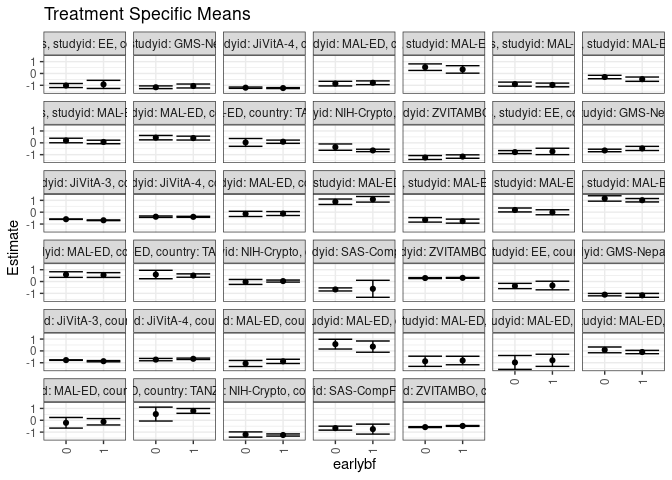

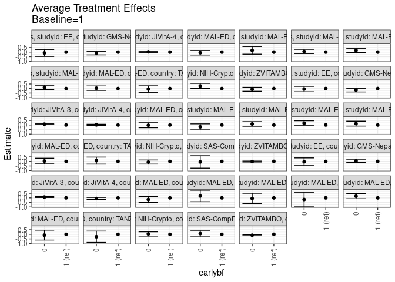

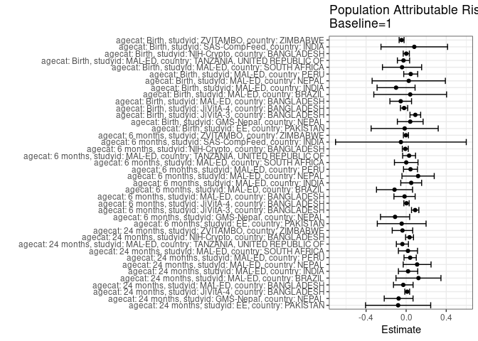

## Results Table

### Parameter: TSM

| agecat | studyid | country | intervention_level | baseline_level | estimate | ci_lower | ci_upper |
| --- | --- | --- | --- | --- | --- | --- | --- |
| Birth | EE | PAKISTAN | 1 | NA | -0.3373148 | -0.6987226 | 0.0240930 |
| Birth | EE | PAKISTAN | 0 | NA | -0.3756217 | -0.5980782 | -0.1531652 |
| Birth | GMS-Nepal | NEPAL | 1 | NA | -1.1668057 | -1.3318032 | -1.0018081 |
| Birth | GMS-Nepal | NEPAL | 0 | NA | -1.1070464 | -1.2092855 | -1.0048072 |
| Birth | JiVitA-3 | BANGLADESH | 1 | NA | -0.8694274 | -0.9201431 | -0.8187117 |
| Birth | JiVitA-3 | BANGLADESH | 0 | NA | -0.7774000 | -0.7968985 | -0.7579016 |
| Birth | JiVitA-4 | BANGLADESH | 1 | NA | -0.6678366 | -0.7270610 | -0.6086123 |
| Birth | JiVitA-4 | BANGLADESH | 0 | NA | -0.7350599 | -0.8321072 | -0.6380125 |
| Birth | MAL-ED | BANGLADESH | 1 | NA | -0.8848393 | -1.0633827 | -0.7062960 |
| Birth | MAL-ED | BANGLADESH | 0 | NA | -1.0630855 | -1.3173558 | -0.8088153 |
| Birth | MAL-ED | BRAZIL | 1 | NA | 0.3626386 | -0.1115112 | 0.8367884 |
| Birth | MAL-ED | BRAZIL | 0 | NA | 0.5697710 | 0.1570990 | 0.9824430 |
| Birth | MAL-ED | INDIA | 1 | NA | -0.8115332 | -1.1703195 | -0.4527469 |
| Birth | MAL-ED | INDIA | 0 | NA | -0.8770605 | -1.3063506 | -0.4477703 |
| Birth | MAL-ED | NEPAL | 1 | NA | -0.7943581 | -1.3075407 | -0.2811754 |
| Birth | MAL-ED | NEPAL | 0 | NA | -0.9747901 | -1.5593909 | -0.3901894 |
| Birth | MAL-ED | PERU | 1 | NA | -0.0975835 | -0.2373164 | 0.0421494 |
| Birth | MAL-ED | PERU | 0 | NA | 0.0862469 | -0.1576183 | 0.3301121 |
| Birth | MAL-ED | SOUTH AFRICA | 1 | NA | -0.1279385 | -0.3972957 | 0.1414187 |
| Birth | MAL-ED | SOUTH AFRICA | 0 | NA | -0.2145532 | -0.6640834 | 0.2349769 |
| Birth | MAL-ED | TANZANIA, UNITED REPUBLIC OF | 1 | NA | 0.7890374 | 0.5857247 | 0.9923502 |
| Birth | MAL-ED | TANZANIA, UNITED REPUBLIC OF | 0 | NA | 0.5216535 | -0.0652118 | 1.1085188 |
| Birth | NIH-Crypto | BANGLADESH | 1 | NA | -1.2454728 | -1.3355284 | -1.1554171 |
| Birth | NIH-Crypto | BANGLADESH | 0 | NA | -1.2050025 | -1.4248200 | -0.9851850 |
| Birth | SAS-CompFeed | INDIA | 1 | NA | -0.7487237 | -1.1696455 | -0.3278020 |
| Birth | SAS-CompFeed | INDIA | 0 | NA | -0.6673548 | -0.8346498 | -0.5000599 |
| Birth | ZVITAMBO | ZIMBABWE | 1 | NA | -0.4806057 | -0.5168950 | -0.4443163 |
| Birth | ZVITAMBO | ZIMBABWE | 0 | NA | -0.5786428 | -0.6167764 | -0.5405092 |
| 6 months | EE | PAKISTAN | 1 | NA | -0.7278903 | -0.9987807 | -0.4570000 |
| 6 months | EE | PAKISTAN | 0 | NA | -0.7838484 | -0.9111027 | -0.6565940 |
| 6 months | GMS-Nepal | NEPAL | 1 | NA | -0.4737319 | -0.6484102 | -0.2990536 |
| 6 months | GMS-Nepal | NEPAL | 0 | NA | -0.6456505 | -0.7532074 | -0.5380936 |
| 6 months | JiVitA-3 | BANGLADESH | 1 | NA | -0.6835850 | -0.7150469 | -0.6521231 |
| 6 months | JiVitA-3 | BANGLADESH | 0 | NA | -0.5933367 | -0.6133690 | -0.5733044 |
| 6 months | JiVitA-4 | BANGLADESH | 1 | NA | -0.3932419 | -0.4382934 | -0.3481903 |
| 6 months | JiVitA-4 | BANGLADESH | 0 | NA | -0.3842048 | -0.4452938 | -0.3231157 |
| 6 months | MAL-ED | BANGLADESH | 1 | NA | -0.1155484 | -0.2813813 | 0.0502844 |
| 6 months | MAL-ED | BANGLADESH | 0 | NA | -0.1452951 | -0.3645244 | 0.0739342 |
| 6 months | MAL-ED | BRAZIL | 1 | NA | 1.0880756 | 0.8525976 | 1.3235536 |
| 6 months | MAL-ED | BRAZIL | 0 | NA | 0.8811177 | 0.6514846 | 1.1107507 |
| 6 months | MAL-ED | INDIA | 1 | NA | -0.7583875 | -0.9290289 | -0.5877461 |
| 6 months | MAL-ED | INDIA | 0 | NA | -0.6470721 | -0.8362551 | -0.4578890 |
| 6 months | MAL-ED | NEPAL | 1 | NA | -0.0087512 | -0.2201463 | 0.2026438 |
| 6 months | MAL-ED | NEPAL | 0 | NA | 0.1869652 | 0.0207422 | 0.3531882 |
| 6 months | MAL-ED | PERU | 1 | NA | 1.0094969 | 0.8660382 | 1.1529556 |
| 6 months | MAL-ED | PERU | 0 | NA | 1.1587201 | 0.9311431 | 1.3862970 |
| 6 months | MAL-ED | SOUTH AFRICA | 1 | NA | 0.5494873 | 0.3488616 | 0.7501129 |
| 6 months | MAL-ED | SOUTH AFRICA | 0 | NA | 0.5896353 | 0.3526312 | 0.8266395 |
| 6 months | MAL-ED | TANZANIA, UNITED REPUBLIC OF | 1 | NA | 0.5069392 | 0.3654833 | 0.6483952 |
| 6 months | MAL-ED | TANZANIA, UNITED REPUBLIC OF | 0 | NA | 0.5932294 | 0.2366770 | 0.9497819 |
| 6 months | NIH-Crypto | BANGLADESH | 1 | NA | 0.0382712 | -0.0471330 | 0.1236755 |
| 6 months | NIH-Crypto | BANGLADESH | 0 | NA | -0.0332120 | -0.2407199 | 0.1742959 |
| 6 months | SAS-CompFeed | INDIA | 1 | NA | -0.6132708 | -1.3327084 | 0.1061669 |
| 6 months | SAS-CompFeed | INDIA | 0 | NA | -0.6684441 | -0.7980831 | -0.5388051 |
| 6 months | ZVITAMBO | ZIMBABWE | 1 | NA | 0.3095441 | 0.2727709 | 0.3463173 |
| 6 months | ZVITAMBO | ZIMBABWE | 0 | NA | 0.2948522 | 0.2539720 | 0.3357323 |
| 24 months | EE | PAKISTAN | 1 | NA | -0.9243122 | -1.2670991 | -0.5815253 |
| 24 months | EE | PAKISTAN | 0 | NA | -1.0185004 | -1.1900476 | -0.8469532 |
| 24 months | GMS-Nepal | NEPAL | 1 | NA | -1.0588717 | -1.2261992 | -0.8915442 |
| 24 months | GMS-Nepal | NEPAL | 0 | NA | -1.1647923 | -1.2780015 | -1.0515830 |
| 24 months | JiVitA-4 | BANGLADESH | 1 | NA | -1.2335728 | -1.2736242 | -1.1935214 |
| 24 months | JiVitA-4 | BANGLADESH | 0 | NA | -1.2016963 | -1.2563542 | -1.1470385 |
| 24 months | MAL-ED | BANGLADESH | 1 | NA | -0.7855577 | -0.9437841 | -0.6273314 |
| 24 months | MAL-ED | BANGLADESH | 0 | NA | -0.8574254 | -1.0531418 | -0.6617090 |
| 24 months | MAL-ED | BRAZIL | 1 | NA | 0.3398400 | 0.0243738 | 0.6553063 |
| 24 months | MAL-ED | BRAZIL | 0 | NA | 0.5309976 | 0.2542538 | 0.8077415 |
| 24 months | MAL-ED | INDIA | 1 | NA | -0.9707759 | -1.1269093 | -0.8146425 |
| 24 months | MAL-ED | INDIA | 0 | NA | -0.9023198 | -1.0750676 | -0.7295720 |
| 24 months | MAL-ED | NEPAL | 1 | NA | -0.4843320 | -0.6659593 | -0.3027048 |
| 24 months | MAL-ED | NEPAL | 0 | NA | -0.3009588 | -0.4462516 | -0.1556659 |
| 24 months | MAL-ED | PERU | 1 | NA | 0.0714959 | -0.0779841 | 0.2209758 |
| 24 months | MAL-ED | PERU | 0 | NA | 0.1949770 | 0.0040295 | 0.3859245 |
| 24 months | MAL-ED | SOUTH AFRICA | 1 | NA | 0.3972880 | 0.2345890 | 0.5599870 |
| 24 months | MAL-ED | SOUTH AFRICA | 0 | NA | 0.4354998 | 0.2500423 | 0.6209573 |
| 24 months | MAL-ED | TANZANIA, UNITED REPUBLIC OF | 1 | NA | 0.0924133 | -0.0434421 | 0.2282688 |
| 24 months | MAL-ED | TANZANIA, UNITED REPUBLIC OF | 0 | NA | 0.0337351 | -0.2975820 | 0.3650522 |
| 24 months | NIH-Crypto | BANGLADESH | 1 | NA | -0.6440735 | -0.7445536 | -0.5435934 |
| 24 months | NIH-Crypto | BANGLADESH | 0 | NA | -0.3626671 | -0.6284313 | -0.0969030 |
| 24 months | ZVITAMBO | ZIMBABWE | 1 | NA | -1.1602465 | -1.3043441 | -1.0161488 |
| 24 months | ZVITAMBO | ZIMBABWE | 0 | NA | -1.2417870 | -1.4095846 | -1.0739894 |

### Parameter: E(Y)

| agecat | studyid | country | intervention_level | baseline_level | estimate | ci_lower | ci_upper |
| --- | --- | --- | --- | --- | --- | --- | --- |
| Birth | EE | PAKISTAN | NA | NA | -0.3522059 | -0.5428560 | -0.1615557 |
| Birth | GMS-Nepal | NEPAL | NA | NA | -1.1260580 | -1.2184297 | -1.0336863 |
| Birth | JiVitA-3 | BANGLADESH | NA | NA | -0.7778811 | -0.7969145 | -0.7588476 |
| Birth | JiVitA-4 | BANGLADESH | NA | NA | -0.6886269 | -0.7410452 | -0.6362086 |
| Birth | MAL-ED | BANGLADESH | NA | NA | -0.9390654 | -1.0847642 | -0.7933666 |
| Birth | MAL-ED | BRAZIL | NA | NA | 0.4029032 | 0.0896793 | 0.7161272 |
| Birth | MAL-ED | INDIA | NA | NA | -0.9122727 | -1.1899971 | -0.6345483 |
| Birth | MAL-ED | NEPAL | NA | NA | -0.7684615 | -1.1257770 | -0.4111460 |
| Birth | MAL-ED | PERU | NA | NA | -0.0520175 | -0.1725298 | 0.0684947 |
| Birth | MAL-ED | SOUTH AFRICA | NA | NA | -0.1690000 | -0.3880340 | 0.0500340 |
| Birth | MAL-ED | TANZANIA, UNITED REPUBLIC OF | NA | NA | 0.7624348 | 0.5710709 | 0.9537986 |
| Birth | NIH-Crypto | BANGLADESH | NA | NA | -1.2441513 | -1.3281130 | -1.1601897 |
| Birth | SAS-CompFeed | INDIA | NA | NA | -0.6676026 | -0.8422097 | -0.4929956 |
| Birth | ZVITAMBO | ZIMBABWE | NA | NA | -0.5262098 | -0.5537283 | -0.4986913 |
| 6 months | EE | PAKISTAN | NA | NA | -0.7725778 | -0.8877440 | -0.6574117 |
| 6 months | GMS-Nepal | NEPAL | NA | NA | -0.5843738 | -0.6761994 | -0.4925481 |
| 6 months | JiVitA-3 | BANGLADESH | NA | NA | -0.5935161 | -0.6130518 | -0.5739805 |
| 6 months | JiVitA-4 | BANGLADESH | NA | NA | -0.3898055 | -0.4270507 | -0.3525603 |
| 6 months | MAL-ED | BANGLADESH | NA | NA | -0.1316250 | -0.2604010 | -0.0028490 |
| 6 months | MAL-ED | BRAZIL | NA | NA | 0.9720774 | 0.8078144 | 1.1363403 |
| 6 months | MAL-ED | INDIA | NA | NA | -0.7079979 | -0.8344175 | -0.5815783 |
| 6 months | MAL-ED | NEPAL | NA | NA | 0.1104308 | -0.0208643 | 0.2417259 |
| 6 months | MAL-ED | PERU | NA | NA | 1.0528816 | 0.9313005 | 1.1744626 |
| 6 months | MAL-ED | SOUTH AFRICA | NA | NA | 0.5500267 | 0.3964966 | 0.7035568 |
| 6 months | MAL-ED | TANZANIA, UNITED REPUBLIC OF | NA | NA | 0.5362213 | 0.4049390 | 0.6675036 |
| 6 months | NIH-Crypto | BANGLADESH | NA | NA | 0.0297622 | -0.0491685 | 0.1086930 |
| 6 months | SAS-CompFeed | INDIA | NA | NA | -0.6657084 | -0.8024377 | -0.5289791 |
| 6 months | ZVITAMBO | ZIMBABWE | NA | NA | 0.3072633 | 0.2799882 | 0.3345385 |
| 24 months | EE | PAKISTAN | NA | NA | -1.0044512 | -1.1543739 | -0.8545285 |
| 24 months | GMS-Nepal | NEPAL | NA | NA | -1.1339602 | -1.2266932 | -1.0412272 |
| 24 months | JiVitA-4 | BANGLADESH | NA | NA | -1.2231088 | -1.2549632 | -1.1912543 |
| 24 months | MAL-ED | BANGLADESH | NA | NA | -0.8141706 | -0.9363085 | -0.6920327 |
| 24 months | MAL-ED | BRAZIL | NA | NA | 0.4626233 | 0.2567495 | 0.6684971 |
| 24 months | MAL-ED | INDIA | NA | NA | -0.9516520 | -1.0670654 | -0.8362385 |
| 24 months | MAL-ED | NEPAL | NA | NA | -0.3749123 | -0.4886073 | -0.2612173 |
| 24 months | MAL-ED | PERU | NA | NA | 0.1111982 | -0.0118399 | 0.2342362 |
| 24 months | MAL-ED | SOUTH AFRICA | NA | NA | 0.4152943 | 0.2928804 | 0.5377083 |
| 24 months | MAL-ED | TANZANIA, UNITED REPUBLIC OF | NA | NA | 0.0547975 | -0.0703378 | 0.1799328 |
| 24 months | NIH-Crypto | BANGLADESH | NA | NA | -0.6103502 | -0.7050157 | -0.5156847 |
| 24 months | ZVITAMBO | ZIMBABWE | NA | NA | -1.1970712 | -1.3045749 | -1.0895676 |

### Parameter: ATE

| agecat | studyid | country | intervention_level | baseline_level | estimate | ci_lower | ci_upper |
| --- | --- | --- | --- | --- | --- | --- | --- |
| Birth | EE | PAKISTAN | 1 | 1 | 0.0000000 | 0.0000000 | 0.0000000 |
| Birth | EE | PAKISTAN | 0 | 1 | -0.0383069 | -0.4615971 | 0.3849834 |
| Birth | GMS-Nepal | NEPAL | 1 | 1 | 0.0000000 | 0.0000000 | 0.0000000 |
| Birth | GMS-Nepal | NEPAL | 0 | 1 | 0.0597593 | -0.1219024 | 0.2414210 |
| Birth | JiVitA-3 | BANGLADESH | 1 | 1 | 0.0000000 | 0.0000000 | 0.0000000 |
| Birth | JiVitA-3 | BANGLADESH | 0 | 1 | 0.0920274 | 0.0374797 | 0.1465750 |
| Birth | JiVitA-4 | BANGLADESH | 1 | 1 | 0.0000000 | 0.0000000 | 0.0000000 |
| Birth | JiVitA-4 | BANGLADESH | 0 | 1 | -0.0672233 | -0.1780573 | 0.0436108 |
| Birth | MAL-ED | BANGLADESH | 1 | 1 | 0.0000000 | 0.0000000 | 0.0000000 |
| Birth | MAL-ED | BANGLADESH | 0 | 1 | -0.1782462 | -0.4891698 | 0.1326774 |
| Birth | MAL-ED | BRAZIL | 1 | 1 | 0.0000000 | 0.0000000 | 0.0000000 |
| Birth | MAL-ED | BRAZIL | 0 | 1 | 0.2071323 | -0.4225752 | 0.8368399 |
| Birth | MAL-ED | INDIA | 1 | 1 | 0.0000000 | 0.0000000 | 0.0000000 |
| Birth | MAL-ED | INDIA | 0 | 1 | -0.0655273 | -0.6353278 | 0.5042732 |
| Birth | MAL-ED | NEPAL | 1 | 1 | 0.0000000 | 0.0000000 | 0.0000000 |
| Birth | MAL-ED | NEPAL | 0 | 1 | -0.1804321 | -0.9829429 | 0.6220788 |
| Birth | MAL-ED | PERU | 1 | 1 | 0.0000000 | 0.0000000 | 0.0000000 |
| Birth | MAL-ED | PERU | 0 | 1 | 0.1838305 | -0.0978828 | 0.4655437 |
| Birth | MAL-ED | SOUTH AFRICA | 1 | 1 | 0.0000000 | 0.0000000 | 0.0000000 |
| Birth | MAL-ED | SOUTH AFRICA | 0 | 1 | -0.0866147 | -0.6279356 | 0.4547061 |
| Birth | MAL-ED | TANZANIA, UNITED REPUBLIC OF | 1 | 1 | 0.0000000 | 0.0000000 | 0.0000000 |
| Birth | MAL-ED | TANZANIA, UNITED REPUBLIC OF | 0 | 1 | -0.2673839 | -0.8877110 | 0.3529432 |
| Birth | NIH-Crypto | BANGLADESH | 1 | 1 | 0.0000000 | 0.0000000 | 0.0000000 |
| Birth | NIH-Crypto | BANGLADESH | 0 | 1 | 0.0404703 | -0.1948194 | 0.2757600 |
| Birth | SAS-CompFeed | INDIA | 1 | 1 | 0.0000000 | 0.0000000 | 0.0000000 |
| Birth | SAS-CompFeed | INDIA | 0 | 1 | 0.0813689 | -0.2746785 | 0.4374163 |
| Birth | ZVITAMBO | ZIMBABWE | 1 | 1 | 0.0000000 | 0.0000000 | 0.0000000 |
| Birth | ZVITAMBO | ZIMBABWE | 0 | 1 | -0.0980372 | -0.1467884 | -0.0492859 |
| 6 months | EE | PAKISTAN | 1 | 1 | 0.0000000 | 0.0000000 | 0.0000000 |
| 6 months | EE | PAKISTAN | 0 | 1 | -0.0559580 | -0.3553789 | 0.2434628 |
| 6 months | GMS-Nepal | NEPAL | 1 | 1 | 0.0000000 | 0.0000000 | 0.0000000 |
| 6 months | GMS-Nepal | NEPAL | 0 | 1 | -0.1719186 | -0.3773735 | 0.0335363 |
| 6 months | JiVitA-3 | BANGLADESH | 1 | 1 | 0.0000000 | 0.0000000 | 0.0000000 |
| 6 months | JiVitA-3 | BANGLADESH | 0 | 1 | 0.0902483 | 0.0527158 | 0.1277807 |
| 6 months | JiVitA-4 | BANGLADESH | 1 | 1 | 0.0000000 | 0.0000000 | 0.0000000 |
| 6 months | JiVitA-4 | BANGLADESH | 0 | 1 | 0.0090371 | -0.0639308 | 0.0820050 |
| 6 months | MAL-ED | BANGLADESH | 1 | 1 | 0.0000000 | 0.0000000 | 0.0000000 |
| 6 months | MAL-ED | BANGLADESH | 0 | 1 | -0.0297467 | -0.3057407 | 0.2462474 |
| 6 months | MAL-ED | BRAZIL | 1 | 1 | 0.0000000 | 0.0000000 | 0.0000000 |
| 6 months | MAL-ED | BRAZIL | 0 | 1 | -0.2069579 | -0.5365043 | 0.1225884 |
| 6 months | MAL-ED | INDIA | 1 | 1 | 0.0000000 | 0.0000000 | 0.0000000 |
| 6 months | MAL-ED | INDIA | 0 | 1 | 0.1113154 | -0.1443184 | 0.3669492 |
| 6 months | MAL-ED | NEPAL | 1 | 1 | 0.0000000 | 0.0000000 | 0.0000000 |
| 6 months | MAL-ED | NEPAL | 0 | 1 | 0.1957164 | -0.0732456 | 0.4646783 |
| 6 months | MAL-ED | PERU | 1 | 1 | 0.0000000 | 0.0000000 | 0.0000000 |
| 6 months | MAL-ED | PERU | 0 | 1 | 0.1492232 | -0.1192774 | 0.4177238 |
| 6 months | MAL-ED | SOUTH AFRICA | 1 | 1 | 0.0000000 | 0.0000000 | 0.0000000 |
| 6 months | MAL-ED | SOUTH AFRICA | 0 | 1 | 0.0401481 | -0.2709158 | 0.3512119 |
| 6 months | MAL-ED | TANZANIA, UNITED REPUBLIC OF | 1 | 1 | 0.0000000 | 0.0000000 | 0.0000000 |
| 6 months | MAL-ED | TANZANIA, UNITED REPUBLIC OF | 0 | 1 | 0.0862902 | -0.2984036 | 0.4709841 |
| 6 months | NIH-Crypto | BANGLADESH | 1 | 1 | 0.0000000 | 0.0000000 | 0.0000000 |
| 6 months | NIH-Crypto | BANGLADESH | 0 | 1 | -0.0714832 | -0.2956166 | 0.1526502 |
| 6 months | SAS-CompFeed | INDIA | 1 | 1 | 0.0000000 | 0.0000000 | 0.0000000 |
| 6 months | SAS-CompFeed | INDIA | 0 | 1 | -0.0551733 | -0.7395588 | 0.6292121 |
| 6 months | ZVITAMBO | ZIMBABWE | 1 | 1 | 0.0000000 | 0.0000000 | 0.0000000 |
| 6 months | ZVITAMBO | ZIMBABWE | 0 | 1 | -0.0146919 | -0.0691575 | 0.0397736 |
| 24 months | EE | PAKISTAN | 1 | 1 | 0.0000000 | 0.0000000 | 0.0000000 |
| 24 months | EE | PAKISTAN | 0 | 1 | -0.0941882 | -0.4773533 | 0.2889770 |
| 24 months | GMS-Nepal | NEPAL | 1 | 1 | 0.0000000 | 0.0000000 | 0.0000000 |
| 24 months | GMS-Nepal | NEPAL | 0 | 1 | -0.1059206 | -0.3082233 | 0.0963821 |
| 24 months | JiVitA-4 | BANGLADESH | 1 | 1 | 0.0000000 | 0.0000000 | 0.0000000 |
| 24 months | JiVitA-4 | BANGLADESH | 0 | 1 | 0.0318765 | -0.0359962 | 0.0997491 |
| 24 months | MAL-ED | BANGLADESH | 1 | 1 | 0.0000000 | 0.0000000 | 0.0000000 |
| 24 months | MAL-ED | BANGLADESH | 0 | 1 | -0.0718677 | -0.3230534 | 0.1793181 |
| 24 months | MAL-ED | BRAZIL | 1 | 1 | 0.0000000 | 0.0000000 | 0.0000000 |
| 24 months | MAL-ED | BRAZIL | 0 | 1 | 0.1911576 | -0.2297836 | 0.6120988 |
| 24 months | MAL-ED | INDIA | 1 | 1 | 0.0000000 | 0.0000000 | 0.0000000 |
| 24 months | MAL-ED | INDIA | 0 | 1 | 0.0684561 | -0.1649011 | 0.3018133 |
| 24 months | MAL-ED | NEPAL | 1 | 1 | 0.0000000 | 0.0000000 | 0.0000000 |
| 24 months | MAL-ED | NEPAL | 0 | 1 | 0.1833733 | -0.0494990 | 0.4162456 |
| 24 months | MAL-ED | PERU | 1 | 1 | 0.0000000 | 0.0000000 | 0.0000000 |
| 24 months | MAL-ED | PERU | 0 | 1 | 0.1234811 | -0.1139491 | 0.3609114 |
| 24 months | MAL-ED | SOUTH AFRICA | 1 | 1 | 0.0000000 | 0.0000000 | 0.0000000 |
| 24 months | MAL-ED | SOUTH AFRICA | 0 | 1 | 0.0382118 | -0.2075202 | 0.2839438 |
| 24 months | MAL-ED | TANZANIA, UNITED REPUBLIC OF | 1 | 1 | 0.0000000 | 0.0000000 | 0.0000000 |
| 24 months | MAL-ED | TANZANIA, UNITED REPUBLIC OF | 0 | 1 | -0.0586783 | -0.4176627 | 0.3003061 |
| 24 months | NIH-Crypto | BANGLADESH | 1 | 1 | 0.0000000 | 0.0000000 | 0.0000000 |
| 24 months | NIH-Crypto | BANGLADESH | 0 | 1 | 0.2814064 | -0.0016705 | 0.5644833 |
| 24 months | ZVITAMBO | ZIMBABWE | 1 | 1 | 0.0000000 | 0.0000000 | 0.0000000 |
| 24 months | ZVITAMBO | ZIMBABWE | 0 | 1 | -0.0815405 | -0.3021173 | 0.1390363 |

### Parameter: PAR

| agecat | studyid | country | intervention_level | baseline_level | estimate | ci_lower | ci_upper |
| --- | --- | --- | --- | --- | --- | --- | --- |
| Birth | EE | PAKISTAN | 1 | NA | -0.0148911 | -0.3497567 | 0.3199746 |
| Birth | GMS-Nepal | NEPAL | 1 | NA | 0.0407477 | -0.0878325 | 0.1693278 |
| Birth | JiVitA-3 | BANGLADESH | 1 | NA | 0.0915463 | 0.0383576 | 0.1447350 |
| Birth | JiVitA-4 | BANGLADESH | 1 | NA | -0.0207902 | -0.0566728 | 0.0150923 |
| Birth | MAL-ED | BANGLADESH | 1 | NA | -0.0542261 | -0.1622635 | 0.0538113 |
| Birth | MAL-ED | BRAZIL | 1 | NA | 0.0402646 | -0.3228813 | 0.4034105 |
| Birth | MAL-ED | INDIA | 1 | NA | -0.1007395 | -0.2903296 | 0.0888505 |
| Birth | MAL-ED | NEPAL | 1 | NA | 0.0258965 | -0.3397201 | 0.3915132 |
| Birth | MAL-ED | PERU | 1 | NA | 0.0455660 | -0.0240869 | 0.1152188 |
| Birth | MAL-ED | SOUTH AFRICA | 1 | NA | -0.0410615 | -0.2365724 | 0.1544494 |
| Birth | MAL-ED | TANZANIA, UNITED REPUBLIC OF | 1 | NA | -0.0266026 | -0.0875833 | 0.0343780 |
| Birth | NIH-Crypto | BANGLADESH | 1 | NA | 0.0013214 | -0.0294196 | 0.0320624 |
| Birth | SAS-CompFeed | INDIA | 1 | NA | 0.0811211 | -0.2512352 | 0.4134774 |
| Birth | ZVITAMBO | ZIMBABWE | 1 | NA | -0.0456042 | -0.0701671 | -0.0210413 |
| 6 months | EE | PAKISTAN | 1 | NA | -0.0446875 | -0.2881400 | 0.1987650 |
| 6 months | GMS-Nepal | NEPAL | 1 | NA | -0.1106419 | -0.2561360 | 0.0348522 |
| 6 months | JiVitA-3 | BANGLADESH | 1 | NA | 0.0900688 | 0.0534610 | 0.1266766 |
| 6 months | JiVitA-4 | BANGLADESH | 1 | NA | 0.0034364 | -0.0229396 | 0.0298123 |
| 6 months | MAL-ED | BANGLADESH | 1 | NA | -0.0160766 | -0.1218757 | 0.0897226 |
| 6 months | MAL-ED | BRAZIL | 1 | NA | -0.1159983 | -0.2960867 | 0.0640902 |
| 6 months | MAL-ED | INDIA | 1 | NA | 0.0503896 | -0.0536886 | 0.1544678 |
| 6 months | MAL-ED | NEPAL | 1 | NA | 0.1191820 | -0.0418425 | 0.2802065 |
| 6 months | MAL-ED | PERU | 1 | NA | 0.0433847 | -0.0263578 | 0.1131272 |
| 6 months | MAL-ED | SOUTH AFRICA | 1 | NA | 0.0005394 | -0.1169712 | 0.1180500 |
| 6 months | MAL-ED | TANZANIA, UNITED REPUBLIC OF | 1 | NA | 0.0292821 | -0.0351822 | 0.0937464 |
| 6 months | NIH-Crypto | BANGLADESH | 1 | NA | -0.0085090 | -0.0382241 | 0.0212061 |
| 6 months | SAS-CompFeed | INDIA | 1 | NA | -0.0524376 | -0.7048506 | 0.5999754 |
| 6 months | ZVITAMBO | ZIMBABWE | 1 | NA | -0.0022808 | -0.0276862 | 0.0231247 |
| 24 months | EE | PAKISTAN | 1 | NA | -0.0801390 | -0.4053137 | 0.2450357 |
| 24 months | GMS-Nepal | NEPAL | 1 | NA | -0.0750885 | -0.2189030 | 0.0687260 |
| 24 months | JiVitA-4 | BANGLADESH | 1 | NA | 0.0104640 | -0.0136483 | 0.0345763 |
| 24 months | MAL-ED | BANGLADESH | 1 | NA | -0.0286129 | -0.1263417 | 0.0691159 |
| 24 months | MAL-ED | BRAZIL | 1 | NA | 0.1227832 | -0.1016581 | 0.3472246 |
| 24 months | MAL-ED | INDIA | 1 | NA | 0.0191239 | -0.0772514 | 0.1154993 |
| 24 months | MAL-ED | NEPAL | 1 | NA | 0.1094198 | -0.0295717 | 0.2484112 |
| 24 months | MAL-ED | PERU | 1 | NA | 0.0397023 | -0.0213462 | 0.1007508 |
| 24 months | MAL-ED | SOUTH AFRICA | 1 | NA | 0.0180063 | -0.0773191 | 0.1133318 |
| 24 months | MAL-ED | TANZANIA, UNITED REPUBLIC OF | 1 | NA | -0.0376158 | -0.0978487 | 0.0226170 |
| 24 months | NIH-Crypto | BANGLADESH | 1 | NA | 0.0337233 | -0.0058126 | 0.0732592 |
| 24 months | ZVITAMBO | ZIMBABWE | 1 | NA | -0.0368247 | -0.1391716 | 0.0655221 |